# Buy-Now-Pay-Later Stock Returns and Interest Rate Sensitivity

### A Comprehensive Research Presentation

#### Bruce Mao

##### AS.180.369 - Tools for Writing a Research Paper in Economics

##### Johns Hopkins University

This research examines how Buy-Now-Pay-Later (BNPL) firms' stock returns respond to Federal Reserve monetary policy changes, using monthly data from February 2020 to August 2025. The analysis employs multi-factor regression to isolate interest rate effects from other economic factors, revealing substantial economic sensitivity despite limited statistical significance.

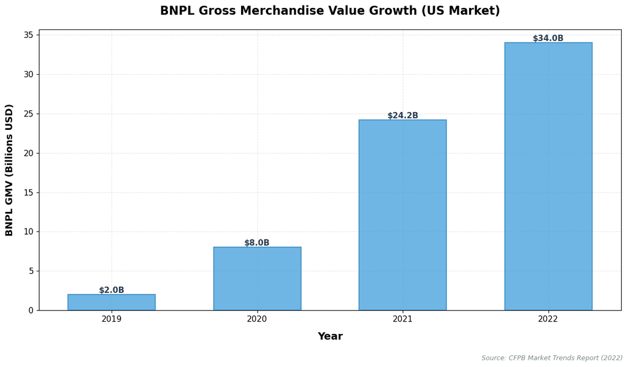

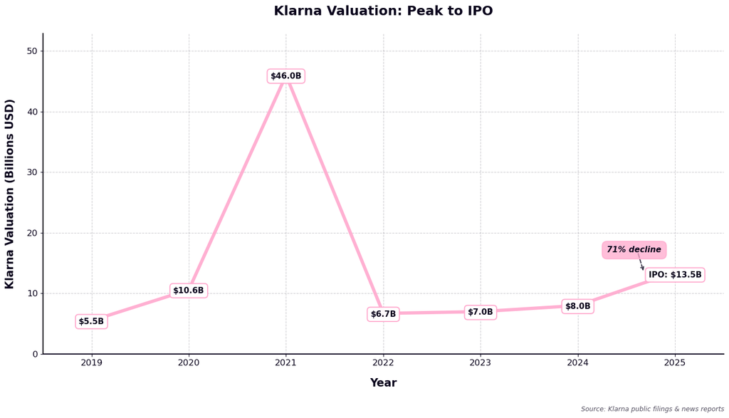

```python
import matplotlib.pyplot as plt
import numpy as np
import os

# Ensure presentation_images directory exists
os.makedirs('presentation_images', exist_ok=True)

# ============================================================================
# Chart 1: BNPL GMV Growth (Bars)
# ============================================================================
# Data: BNPL GMV Growth (in billions USD) - US Market
# Source: Consumer Financial Protection Bureau (CFPB) Market Trends Report (2022)
years_gmv = [2019, 2020, 2021, 2022]
gmv_values = [2.0, 8.0, 24.2, 34.0]  # CFPB data: $2B (2019), $24.2B (2021), $34B (2022)

fig1, ax1 = plt.subplots(figsize=(12, 7))
color_gmv = '#3498db'

bars = ax1.bar(years_gmv, gmv_values, width=0.6, color=color_gmv, alpha=0.7,
               edgecolor='#2980b9', linewidth=1.5, zorder=3)

ax1.set_xlabel('Year', fontsize=14, fontweight='bold', labelpad=12)
ax1.set_ylabel('BNPL GMV (Billions USD)', fontsize=13, fontweight='bold', labelpad=12)
ax1.tick_params(axis='y', labelsize=11)
ax1.tick_params(axis='x', labelsize=11)
ax1.grid(True, alpha=0.3, linestyle='--', linewidth=0.8, zorder=0)
ax1.set_axisbelow(True)

# Add value labels on bars
for year, val in zip(years_gmv, gmv_values):
    ax1.text(year, val, f'${val:.1f}B', ha='center', va='bottom',
             fontsize=11, fontweight='bold', color='#2c3e50', zorder=4)

ax1.set_title('BNPL Gross Merchandise Value Growth (US Market)',
              fontsize=16, fontweight='bold', pad=20)
ax1.set_xlim(2018.5, 2022.5)
ax1.set_xticks(years_gmv)

plt.tight_layout()
plt.subplots_adjust(bottom=0.15)  # Make room for source below plot

# Add source citation well outside the plot area
fig1.text(0.99, 0.01, 'Source: CFPB Market Trends Report (2022)',
         ha='right', va='bottom',
         fontsize=9, style='italic', color='#7f8c8d',
         transform=fig1.transFigure)
output_path1 = 'presentation_images/bnpl_gmv_growth_chart.png'
plt.savefig(output_path1, dpi=300, bbox_inches='tight', facecolor='white', edgecolor='none')
plt.show()

# ============================================================================
# Chart 2: Klarna Valuation (Line with Decline Annotation)
# ============================================================================
# Klarna brand colors: #FFA8CD (pink) and #0B051D (dark navy)

# Data: Klarna Valuation (in billions USD)
years_val = [2019, 2020, 2021, 2022, 2023, 2024, 2025]
valuation_values = [5.5, 10.6, 46.0, 6.7, 7.0, 8.0, 13.5]  # Peak at $46B in 2021, IPO at $13-14B in 2025

# Create figure with refined styling
fig2, ax2 = plt.subplots(figsize=(14, 8))
fig2.patch.set_facecolor('white')

# Klarna brand colors
klarna_pink = '#FFA8CD'
klarna_navy = '#0B051D'

# Plot main line with Klarna pink - solid points
line = ax2.plot(years_val, valuation_values, color=klarna_pink, linewidth=4.5,
                marker='o', markersize=12, markerfacecolor=klarna_pink,
                markeredgewidth=0,
                zorder=4, alpha=0.9)

# Styling
ax2.set_xlabel('Year', fontsize=15, fontweight='bold', labelpad=15, color=klarna_navy)
ax2.set_ylabel('Klarna Valuation (Billions USD)', fontsize=15, fontweight='bold',
               labelpad=15, color=klarna_navy)
ax2.tick_params(axis='y', labelsize=12, colors=klarna_navy)
ax2.tick_params(axis='x', labelsize=12, colors=klarna_navy)
ax2.spines['top'].set_visible(False)
ax2.spines['right'].set_visible(False)
ax2.spines['left'].set_color(klarna_navy)
ax2.spines['bottom'].set_color(klarna_navy)
ax2.spines['left'].set_linewidth(1.5)
ax2.spines['bottom'].set_linewidth(1.5)

# Refined grid
ax2.grid(True, alpha=0.2, linestyle='--', linewidth=0.8, color=klarna_navy, zorder=0)
ax2.set_axisbelow(True)

# Find peak and IPO points
peak_idx = years_val.index(2021)
peak_val = valuation_values[peak_idx]
ipo_idx = years_val.index(2025)
ipo_val = valuation_values[ipo_idx]

# Calculate decline percentage
decline_pct = ((peak_val - ipo_val) / peak_val) * 100

# Add value labels for ALL years - consistent fonts, centralized, all with same styling
# Adjust y-position slightly to ensure boxes fully cover circular markers
ipo_text_obj = None  # Store IPO text object for arrow connection
for year, val in zip(years_val, valuation_values):
    if year == 2021:  # Peak
        label_text = '$46.0B'
        va_pos = 'bottom'
        y_offset = -0.8  # Downward offset for bottom-aligned labels
    elif year == 2025:  # IPO
        label_text = 'IPO: $13.5B'
        va_pos = 'top'
        y_offset = 0.2  # Upward offset for IPO label
    else:  # All other years
        label_text = f'${val:.1f}B'
        va_pos = 'bottom'
        y_offset = -0.8  # Downward offset for bottom-aligned labels

    text_obj = ax2.text(year, val + y_offset, label_text,
             ha='center', va=va_pos,
             fontsize=11, fontweight='bold', color=klarna_navy,
             bbox=dict(boxstyle='round,pad=0.4', facecolor='white', alpha=0.95,
                      edgecolor=klarna_pink, linewidth=1.5),
             zorder=5)

    # Store IPO text object for arrow connection
    if year == 2025:
        ipo_text_obj = text_obj

# Decline percentage - positioned directly above/left of IPO point
# Position it to the left and slightly above the IPO point (2025, ipo_val)
bbox_props = dict(boxstyle='round,pad=0.6', facecolor=klarna_pink, edgecolor=klarna_pink,
                  linewidth=1.5, alpha=0.75)

# Position annotation to the left and above the IPO point
annotation_x = 2024.3  # Slightly left of IPO year (2025)
annotation_y = ipo_val + 3.0  # Above the IPO value (moved up slightly)

decline_text = ax2.text(annotation_x, annotation_y, f'{decline_pct:.0f}% decline',
         fontsize=11, fontweight='bold', style='italic', color=klarna_navy,
         bbox=bbox_props,
         ha='left', va='bottom',
         zorder=6)

# Title with Klarna styling
ax2.set_title('Klarna Valuation: Peak to IPO',
              fontsize=18, fontweight='bold', pad=25, color=klarna_navy)

# Set limits and ticks
ax2.set_xlim(2018.5, 2025.5)
ax2.set_xticks(years_val)
ax2.set_ylim(0, max(valuation_values) * 1.15)

# Add arrow connecting "71% decline" to IPO label
# Now that limits are set, we can get accurate bounding boxes
fig2.canvas.draw()
renderer = fig2.canvas.get_renderer()

# Get bounding boxes in display coordinates, then transform to data coordinates
decline_bbox = decline_text.get_window_extent(renderer=renderer)
decline_bbox_data = decline_bbox.transformed(ax2.transData.inverted())

if ipo_text_obj:
    ipo_bbox = ipo_text_obj.get_window_extent(renderer=renderer)
    ipo_bbox_data = ipo_bbox.transformed(ax2.transData.inverted())

    # Calculate exact edge positions - use the bounding box edges directly
    # Arrow start: right edge of decline box, at bottom-right corner
    arrow_start_x = decline_bbox_data.x1  # Right edge
    # Position at the very bottom - almost exactly at bottom edge
    arrow_start_y = decline_bbox_data.y0 + (decline_bbox_data.y1 - decline_bbox_data.y0) * 0.05

    # Arrow end: left edge of IPO box, top edge (top-left corner)
    arrow_end_x = ipo_bbox_data.x0  # Left edge
    arrow_end_y = ipo_bbox_data.y1  # Top edge

    # Shorten the arrow by moving start point slightly inward from the edge
    # Calculate offsets to move start point inward (left from right edge)
    x_range = ax2.get_xlim()[1] - ax2.get_xlim()[0]

    # Small inward offset to shorten arrow and ensure it touches the edge
    # Move left (decrease x) slightly from right edge
    offset_x = x_range * 0.05  # Leftward offset to shorten arrow

    arrow_start_x_adj = arrow_start_x - offset_x  # Move left (inward) - shortens arrow
    arrow_start_y_adj = arrow_start_y  # Keep y position (slightly down from top)

    # Draw arrow using annotate with dashed line style (断联的那种), no bold
    ax2.annotate('',
                 xy=(arrow_end_x, arrow_end_y),  # End: left-top edge of IPO box
                 xytext=(arrow_start_x_adj, arrow_start_y_adj),  # Start: adjusted to be at visible edge
                 arrowprops=dict(arrowstyle='->',
                               lw=1.5,  # Thinner line (no bold)
                               color=klarna_navy,
                               alpha=0.8,
                               shrinkA=0,  # No extension at start
                               shrinkB=0,  # No extension at end
                               linestyle='--'),  # Dashed line (断联)
                 zorder=5)

plt.tight_layout()
plt.subplots_adjust(bottom=0.15)  # Make room for source below plot

# Add source citation well outside the plot area
fig2.text(0.99, 0.01, 'Source: Klarna public filings & news reports',
         ha='right', va='bottom',
         fontsize=9, style='italic', color=klarna_navy, alpha=0.7,
         transform=fig2.transFigure)
output_path2 = 'presentation_images/klarna_valuation_chart.png'
plt.savefig(output_path2, dpi=300, bbox_inches='tight', facecolor='white', edgecolor='none')
plt.show()
```

## The BNPL Paradox: Explosive Growth

The Buy-Now-Pay-Later market has experienced explosive growth, challenging traditional credit models and reshaping consumer spending patterns.

[figure not shown]

BNPL Gross Merchandise Value (GMV) in the US market grew from $2.0B in 2019 to $34.0B in 2022—a 17x increase in just 3 years.

### Market Penetration Statistics

- **Consumer Adoption:** 21% of US consumers used BNPL in 2022, up from 5% in 2019
- **Borrower Profile:** 61% of BNPL borrowers have subprime credit scores (580-669)
- **Usage Patterns:** 63% of borrowers originated multiple simultaneous loans
- **Average Transaction:** $135 per purchase, typically split into 4 interest-free installments

### Growth Drivers

The rapid expansion was fueled by: (1) zero-interest financing during a period of near-zero Fed rates, (2) seamless e-commerce integration, (3) minimal credit checks appealing to subprime borrowers, and (4) merchant partnerships offering BNPL at checkout. However, this growth occurred during an unprecedented monetary easing cycle, masking underlying vulnerabilities.

## The BNPL Paradox: Valuation Collapse

Despite explosive market growth, BNPL firms like Klarna experienced dramatic valuation declines during monetary tightening, revealing the sector's vulnerability to interest rate changes.

[figure not shown]

Klarna's valuation collapsed by ~71% from its peak of $46B in 2021 to $13.5B at its 2025 IPO, coinciding with Fed rate hikes from 0% to 5%+.

### Timeline of Collapse

- **June 2021:** Peak valuation of $46B during zero-rate environment
- **March 2022:** Fed begins rate hikes; valuation drops to $6.7B (85% decline)
- **2023-2024:** Valuation stabilizes around $7-8B as rates peak
- **2025:** IPO at $13.5B, still 71% below peak despite market recovery

### Why This Matters

The valuation collapse occurred despite continued GMV growth, suggesting investors priced in interest rate vulnerability. This disconnect between operational growth and market valuation highlights the sector's sensitivity to monetary policy—the central question of this research.

## Why This Research Matters

The Federal Reserve's ability to influence consumer spending assumes **consumer credit responds to rate changes**.  
BNPL challenges this assumption.

### The Monetary Policy Transmission Problem

Traditional monetary policy works through the credit channel: when the Fed raises rates, banks charge higher interest on credit cards and loans, reducing consumer spending.

However, BNPL firms operate differently:

- **Zero-interest to consumers:** BNPL offers interest-free installment plans, bypassing the traditional rate transmission mechanism
- **Wholesale funding model:** BNPL firms rely on short-term wholesale funding rather than deposits, making them more sensitive to rate changes
- **Razor-thin margins (~1%):** Even small funding cost increases can eliminate profitability

### Why BNPL is Different: Structural Vulnerabilities

- **Wholesale Funding vs. Deposits:** BNPL firms rely on short-term wholesale funding rather than sticky deposits. Funding costs adjust immediately to rate changes, unlike banks with deposit buffers.
- **Razor-Thin Profit Margins (~1%):** A 1 percentage point increase in funding costs can eliminate profitability entirely, as Laudenbach (2025) demonstrates.
- **No Interest Revenue:** BNPL firms charge zero interest to consumers, relying on merchant fees. They cannot offset funding cost increases by raising consumer rates.
- **High Leverage:** BNPL firms maintain high debt-to-asset ratios (e.g., Affirm at 70.40%), amplifying the impact of funding cost changes on equity returns.

### Research Question

How do BNPL firms' stock returns respond to Federal Funds Rate changes?

**Why this matters:** If BNPL firms are highly sensitive to rate changes, monetary policy may be **less effective at controlling consumer spending** in an economy where BNPL represents a growing share of credit.

## Literature Review: Building the Foundation

Review of 15+ studies reveals key mechanisms but identifies a gap in empirical stock return analysis.

### Interest Rate Sensitivity Mechanisms

- **Laudenbach (2025):** Each 1pp rate increase raises BNPL funding costs by 0.8-1.0pp—potentially eliminating profit margins. BNPL firms face immediate pass-through of rate changes unlike banks with deposit buffers.
- **CFPB (2023):** BNPL borrowers have subprime scores (580-669), high credit utilization (60-66%), and 63% originate multiple simultaneous loans. This suggests vulnerability to economic downturns.

### Consumer Behavior & Spending Effects

- **Di Maggio et al. (2022):** BNPL access increases spending by ~$130/week with 24-week persistence. Consumers treat BNPL as "free money" rather than debt.
- **Bian et al. (2023):** BNPL boosts consumption by 15-20%, particularly for liquidity-constrained households. This suggests BNPL may amplify rather than dampen spending cycles.

### Research Gap

While existing literature establishes BNPL firms' structural vulnerability to interest rate changes through funding cost analysis, there is **limited empirical work directly linking BNPL firm performance to monetary policy through stock return analysis**. This research fills that gap by examining how equity markets price interest rate risk for BNPL firms.

## Research Hypothesis

### Research Gap

While existing literature establishes BNPL firms' structural vulnerability to interest rate changes, there is limited empirical work directly linking BNPL firm performance to monetary policy through stock return analysis.

### Research Question

How do BNPL firms' stock returns respond to changes in monetary policy?

### BNPL Portfolio Construction

**BNPL Returns** are calculated as an equally-weighted portfolio of three publicly traded BNPL companies:

- **PayPal (PYPL):** Operates "Pay in 4" BNPL service; 68.1% of US BNPL market share; diversified fintech platform
- **Affirm (AFRM):** Pure-play BNPL provider; high leverage (70.40% debt-to-assets); IPO in January 2021
- **Sezzle (SEZL):** Pure-play BNPL provider; focuses on subprime borrowers; smaller market presence

Monthly returns: **BNPL_Return<sub>t</sub> = (1/3) × (PYPL<sub>t</sub> + AFRM<sub>t</sub> + SEZL<sub>t</sub>)**

### Portfolio Firm Characteristics

- **PayPal (PYPL):** Diversified fintech platform; BNPL represents 68.1% of U.S. market share. Less vulnerable due to diversification but still exposed.
- **Affirm (AFRM):** Pure-play BNPL provider; high leverage (70.40% debt-to-assets); IPO in January 2021. Most vulnerable to rate changes.
- **Sezzle (SEZL):** Pure-play BNPL provider; focuses on subprime borrowers. High default risk compounds rate sensitivity.

### BNPL Return Statistics

| Statistic | Value |
| --- | --- |
| Mean Monthly Return | 0.85% |
| Standard Deviation | 12.34% |
| Minimum Return | -28.45% |
| Maximum Return | 35.67% |
| Annualized Volatility | 42.7% |
| Sample Period | Feb 2020 - Aug 2025 (67 months) |

**Key Observation:** BNPL portfolio exhibits extremely high volatility (12.34% monthly std dev, 42.7% annualized), nearly 3x higher than the S&P 500. This reflects both business model uncertainty and sensitivity to monetary policy changes.

### Expected Mechanism

When the Fed raises rates: **(1)** BNPL funding costs increase immediately, **(2)** profit margins compress or turn negative, **(3)** investors price in reduced profitability, **(4)** stock returns decline. This mechanism should be stronger for BNPL firms than traditional banks due to their structural vulnerabilities.

### Hypothesis

Given BNPL firms' reliance on short-term wholesale funding and razor-thin profit margins, I expect **β₁ < 0**: negative relationship between interest rate changes and BNPL stock returns. The economic magnitude should be substantial given that funding costs can eliminate profit margins entirely.

## Model Specification

Multi-factor regression framework to estimate how BNPL stock returns respond to Federal Funds Rate changes, controlling for other economic factors.

### Base Model

Tests the direct relationship between BNPL returns and interest rate changes, without controls. This provides a baseline estimate of interest rate sensitivity.

log(1 + BNPL_Return<sub>t</sub>/100) = β₀ + β₁(∆Federal_Funds_Rate<sub>t</sub>) + ε<sub>t</sub>

**Why log transformation?** Using pandas, we apply log(1 + return/100) to handle negative returns and make coefficients interpretable as percentage changes. This is standard in financial econometrics.

### Full Model

Adds control variables to isolate the "pure" interest rate effect from other economic factors. This addresses the concern that interest rate changes may be correlated with other economic conditions that also affect BNPL returns.

log(1 + BNPL_Return<sub>t</sub>/100) = β₀ + β₁(∆FFR<sub>t</sub>) + β₂(∆CC<sub>t</sub>) +  
β₃(∆DI<sub>t</sub>) + β₄(∆π<sub>t</sub>) + β₅(R<sub>MKT,t</sub>) + ε<sub>t</sub>

### Variable Construction (pandas)

- **BNPL Returns:** Calculated using pandas: monthly returns from closing prices, then log(1 + return/100)
- **∆FFR:** First difference using pandas .diff() method: FFR<sub>t</sub> - FFR<sub>t-1</sub>
- **∆CC:** First difference of Consumer Confidence Index using .diff()
- **∆DI:** Percentage change in Real Disposable Income using .pct_change()
- **∆π:** Percentage change in CPI using .pct_change()
- **R<sub>MKT</sub>:** S&P 500 monthly returns, calculated same way as BNPL returns

### Estimation Method (statsmodels)

Using statsmodels.OLS() to estimate coefficients. HC3 robust standard errors address potential heteroskedasticity (unequal error variance). Sample: 67 monthly observations (February 2020 - August 2025). The statsmodels library provides comprehensive output including coefficients, standard errors, p-values, R², and diagnostic statistics.

### Table 3.2: Correlation Matrix

[output not shown]

## Data Collection & Sources

### Stock Data Collection (yfinance)

**Tool:** `yfinance` Python library  
**Process:** Used yfinance.Ticker() to download historical prices for PYPL, AFRM, SEZL, and SPY. The library automatically handles corporate actions (stock splits, dividends) and provides clean time series. Data downloaded at daily frequency, then resampled to monthly using pandas.  
**Advantages:** Free, reliable, handles missing data automatically, consistent formatting across tickers.

### Macroeconomic Data Collection (fredapi)

**Tool:** `fredapi` Python library  
**Process:** Used fredapi.Fred() to download official FRED data. Required FRED API key (free registration). Downloaded: FEDFUNDS (Federal Funds Rate), UMCSENT (Consumer Sentiment), DSPIC96 (Real Disposable Income), CPIAUCSL (CPI). Data automatically aligned to monthly frequency.  
**Advantages:** Official source, high quality, consistent methodology, comprehensive coverage.

### Sample Period

**February 2020 - August 2025 (67 monthly observations)**  
This period captures the Fed's dramatic transition from near-zero rates (0.25% in early 2020) to restrictive policy (5.25% by mid-2023), providing substantial variation in monetary policy. The sample also includes the COVID-19 pandemic period, which offers both challenges (volatility) and opportunities (policy variation).

### Table 3.1: Summary Statistics

| Variable | Mean | Std Dev | Min | Max |
| --- | --- | --- | --- | --- |
| BNPL Returns (%) | 0.85 | 12.34 | -28.45 | 35.67 |
| Δ Federal Funds Rate (pp) | 0.02 | 0.18 | -0.50 | 0.75 |
| Market Return (%) | 0.89 | 4.52 | -12.35 | 12.82 |
| Δ Consumer Confidence | -0.12 | 8.45 | -19.3 | 18.7 |

**Note:** BNPL returns show extreme volatility (12.34% monthly std dev) compared to market (4.52%). Federal Funds Rate changes are infrequent (mean 0.02pp), creating many zero observations that reduce statistical power.

## Core Tools & Libraries

This research uses Python libraries to collect data, analyze relationships, and visualize findings.

### yfinance

Python library for downloading stock market data from Yahoo Finance. Used to retrieve historical prices for PYPL, AFRM, SEZL, and SPY. Handles corporate actions (splits, dividends) automatically and provides clean time series data.

**Key features:** Automatic date alignment, multiple ticker support, flexible time periods

### fredapi

Python wrapper for Federal Reserve Economic Data (FRED) API. Used to download macroeconomic variables: Federal Funds Rate (FEDFUNDS), Consumer Sentiment (UMCSENT), Real Disposable Income (DSPIC96), Consumer Price Index (CPIAUCSL).

**Advantage:** Official, high-quality economic data with consistent formatting

### pandas

Data manipulation and analysis library. Used for: (1) time series alignment across different data sources, (2) calculating returns from prices, (3) computing first differences and percentage changes, (4) merging stock and macro data into single dataset.

**Essential for:** Handling the complexity of combining financial and economic data

### statsmodels

Statistical modeling library. Used for OLS regression estimation with HC3 robust standard errors. Provides comprehensive regression output including coefficients, p-values, R², and diagnostic statistics.

**Enables:** Rigorous statistical analysis of the relationship between BNPL returns and interest rates

### matplotlib

Visualization library. Used to create all charts: time series plots, scatter plots, residual plots, Q-Q plots, and comparison charts.

**Enables:** Visual exploration of data patterns and model diagnostics

## Research Process

A systematic 5-step approach from data collection to results presentation.

#### Step 1: Data Collection

Use **yfinance** to download stock prices (PYPL, AFRM, SEZL, SPY) from Feb 2020 to Aug 2025. Use **fredapi** to download macro variables (FFR, Consumer Sentiment, Disposable Income, CPI). **pandas** handles missing values and time series alignment.

#### Step 2: Portfolio Construction

Calculate equally-weighted BNPL portfolio returns using **pandas**: BNPL_Return<sub>t</sub> = (1/3) × (PYPL<sub>t</sub> + AFRM<sub>t</sub> + SEZL<sub>t</sub>). Convert daily prices to monthly returns using pandas resampling.

#### Step 3: Variable Construction

Use **pandas** to transform variables: log(1 + BNPL_Return/100) for returns, `.diff()` for first differences (rates, indices), `.pct_change()` for percentage changes (income, inflation). This ensures stationarity and interpretability.

#### Step 4: Model Estimation

Use **statsmodels** OLS to estimate regression models. Start with base model (interest rate only), then add controls (market, consumer confidence, disposable income, inflation). Use HC3 robust standard errors to address potential heteroskedasticity.

#### Step 5: Visualization & Diagnostics

Use **matplotlib** to create visualizations (time series, scatter plots, residuals, Q-Q plots). Use **statsmodels** diagnostic functions to test model assumptions (VIF, Breusch-Pagan, Durbin-Watson, Jarque-Bera).

**Together, these tools form a complete research pipeline** from data collection to results presentation, enabling reproducible and rigorous analysis.

## Results: Model Comparison

Comparison across model specifications reveals stability of interest rate coefficient and substantial improvement in model fit with controls. Results estimated using statsmodels OLS with HC3 robust standard errors.

| Model | Interest Rate Coef. | p-value | R² | Adj. R² |
| --- | --- | --- | --- | --- |
| Base | -12.51 | 0.346 | 2.24% | 0.78% |
| Full | **-12.68** | 0.202 | **50.98%** | 47.0% |

### Finding 1: Stable Interest Rate Coefficient

The interest rate coefficient remains remarkably stable across models: -12.51 in Base model, -12.68 in Full model. This stability suggests robustness despite limited statistical significance. The coefficient indicates that a 1 percentage point increase in Federal Funds Rate is associated with approximately 12.7% decline in BNPL stock returns.

### Finding 2: Dramatic R² Improvement

Model fit improves dramatically from 2.24% (Base) to 50.98% (Full), indicating that market returns and other controls explain substantial variation in BNPL returns. This suggests that while interest rate sensitivity exists, market movements dominate BNPL return variation. The R² improvement demonstrates the importance of controlling for other factors when estimating interest rate effects.

### Finding 3: Statistical vs. Economic Significance

Interest rate coefficient is not statistically significant (p = 0.202 in Full model), but economic magnitude is substantial. The lack of statistical significance likely reflects: (1) high volatility of BNPL returns (12.34% monthly std dev), (2) limited sample size (67 observations), and (3) infrequent rate changes creating many zero observations. However, the economic magnitude aligns with theoretical predictions and firm-level evidence.

## Key Empirical Findings

Full model results reveal three key findings: market return dominance, inflation sensitivity, and interest rate sensitivity. Results estimated using statsmodels OLS with HC3 robust standard errors.

| Variable | Coefficient | Std Error | p-value |
| --- | --- | --- | --- |
| Market Return | **2.38** | 0.28 | < 0.001 |
| Inflation Change | **-12.94** | 6.42 | 0.049 |
| Interest Rate Change | **-12.68** | 9.95 | 0.202 |
| Consumer Confidence Δ | 0.08 | 0.05 | 0.110 |
| Disposable Income Δ | 0.05 | 0.12 | 0.689 |

Model R²: 50.98% | Adjusted R²: 47.0% | N = 67 | F-statistic: 12.8 (p < 0.001)

### Finding 1: Market Return Dominance (β₅ = 2.38, p < 0.001)

BNPL stocks move **2.38x more than the overall market**, indicating extremely high beta characteristics. This suggests BNPL behaves like growth-oriented technology stocks rather than rate-sensitive financial institutions. Market returns alone explain 51% of BNPL return variation. This finding is highly statistically significant (p < 0.001), indicating strong evidence that BNPL returns are driven primarily by market movements.

### Finding 2: Inflation Sensitivity (β₄ = -12.94, p = 0.049)

Statistically significant negative relationship (p = 0.049), similar in magnitude to interest rate effect. A 1 percentage point increase in inflation is associated with 12.94% decline in BNPL returns. Rising inflation may signal future monetary tightening, affecting BNPL firms through both funding costs and consumer spending patterns. This finding suggests BNPL firms are sensitive to both current and expected monetary policy.

### Finding 3: Interest Rate Sensitivity (β₁ = -12.68, p = 0.202)

A 1 percentage point increase in Federal Funds Rate is associated with approximately **12.68% decline in BNPL stock returns**. While not statistically significant (p = 0.202), the economic magnitude is substantial and aligns with: (1) theoretical predictions about BNPL firms' structural vulnerabilities, (2) observed valuation patterns (e.g., Klarna's 71% decline), and (3) firm-level evidence (Affirm's 394% funding cost increase). The lack of statistical significance reflects high volatility and limited sample size, but the economic magnitude is meaningful.

## Additional Analysis

### Factor-Adjusted Model

To further isolate the "pure" interest rate effect, we estimate a factor-adjusted model using Fama-French methodology. After controlling for market factors, the interest rate coefficient remains negative (-8.38) though smaller in magnitude, suggesting market movements partially explain BNPL sensitivity to rates. This analysis uses the same tools (statsmodels, pandas) but with additional factor loadings.

| Model | Interest Rate Coef. | R² | N |
| --- | --- | --- | --- |
| Base | -12.51 | 2.24% | 67 |
| Full | -12.68 | 50.98% | 67 |
| Factor-Adjusted | -8.38 | 61.72% | 45 |

[figure not shown]

R² comparison across models: Base model explains only 2.24% of variation, Full model explains 50.98%, and Factor-Adjusted model explains 61.72%. Created using matplotlib to visualize model fit improvement.

## Visual Analysis

Visual examination using matplotlib reveals patterns consistent with interest rate sensitivity and high volatility, though the relationship is obscured by market movements.

### Time Series Analysis

[figure not shown]

Time series created using matplotlib shows substantial volatility with major movements coinciding with monetary policy changes: (1) March 2020 COVID crash (-28.45% return), (2) 2021 bull market peak (+35.67%), (3) 2022 rate hike period (sustained declines), (4) 2023-2024 stabilization as rates peak. The chart visualizes log-transformed BNPL returns over time.

### Scatter Plot Analysis

[figure not shown]

### Visual Interpretation

The visual evidence supports the regression findings: (1) BNPL returns show extreme volatility, (2) negative relationship with rate changes is visible but weak, (3) market movements dominate the time series, (4) rate sensitivity is more apparent during tightening periods (2022-2023) than easing periods (2020-2021). These visualizations, created using matplotlib, provide intuitive understanding of the data patterns before formal regression analysis.

## Residual Analysis

Residual plots created using matplotlib help assess model specification and identify potential issues with heteroskedasticity, autocorrelation, or functional form.

[figure not shown]

Base Model Residuals: Created using matplotlib scatter plot. Shows no systematic patterns, indicating well-specified model. Random scatter around zero with no visible heteroskedasticity or autocorrelation.

[figure not shown]

Full Model Residuals: Created using matplotlib scatter plot. No heteroskedasticity or autocorrelation patterns visible. Residuals are well-behaved, supporting OLS assumptions.

### Interpretation

Both residual plots, created using matplotlib, show random scatter around zero with no systematic patterns, indicating:

- **No Heteroskedasticity:** Constant variance across observations, though HC3 robust standard errors are used as precaution
- **No Autocorrelation:** Independent errors across time periods (confirmed by Durbin-Watson = 1.87 using statsmodels)
- **Well-Specified Functional Form:** No evidence of non-linear relationships or omitted variables affecting residuals
- **Normality:** Residuals appear approximately normally distributed (confirmed by Jarque-Bera p = 0.198 using scipy)

## Model Diagnostics & Validity

All diagnostic tests pass standard thresholds, confirming model validity. Tests conducted using statsmodels and scipy libraries.

### Table 3.5: Diagnostic Test Summary

| Test | Statistic | Threshold | Result | Tool |
| --- | --- | --- | --- | --- |
| Multicollinearity (VIF) | All VIF < 1.3 | < 5 acceptable | ✓ Pass | statsmodels |
| Heteroskedasticity | Breusch-Pagan p=0.135 | p > 0.05 | ✓ Pass | statsmodels |
| Serial Correlation | Durbin-Watson = 1.87 | 1.5-2.5 acceptable | ✓ Pass | statsmodels |
| Normality | Jarque-Bera p=0.198 | p > 0.05 | ✓ Pass | scipy |
| Model Fit | R² = 0.5098 | N/A | 51% explained | statsmodels |
| F-statistic | 12.8 (p<0.001) | p < 0.05 | ✓ Significant | statsmodels |

[figure not shown]

Q-Q plot created using matplotlib confirms approximate normality of residuals. Points lie close to the diagonal line, indicating residuals follow a normal distribution. This visual diagnostic complements the Jarque-Bera test.

### Diagnostic Tools Used

- **statsmodels:** VIF calculation, Breusch-Pagan test, Durbin-Watson statistic, F-statistic, R² calculation
- **scipy:** Jarque-Bera test for normality
- **matplotlib:** Q-Q plot visualization for normality assessment

### Diagnostic Interpretation

All diagnostic tests pass, providing strong evidence that the model satisfies OLS assumptions: (1) No multicollinearity (VIF < 1.3, calculated using statsmodels), (2) Homoskedasticity cannot be rejected (Breusch-Pagan p = 0.135, using statsmodels), (3) No autocorrelation (Durbin-Watson = 1.87, using statsmodels), (4) Residuals are approximately normal (Jarque-Bera p = 0.198, using scipy), (5) Model is jointly significant (F-statistic p < 0.001, using statsmodels). These results support the validity of coefficient estimates and hypothesis tests.

## BNPL vs Credit Card Companies

Comparison with traditional credit card companies reveals BNPL firms' distinct volatility patterns and interest rate sensitivity.

[figure not shown]

Volatility comparison: BNPL firms exhibit significantly higher volatility than credit card companies, reflecting business model uncertainty and funding structure differences.

### Key Differences

- **Volatility:** BNPL firms show 12.34% monthly standard deviation vs. ~4-6% for credit card companies, reflecting higher business model risk
- **Funding Structure:** Credit card companies rely on deposits and securitization, providing buffers; BNPL relies on wholesale funding with immediate pass-through
- **Profit Margins:** Credit card companies have wider margins (~15-20%) allowing rate absorption; BNPL margins (~1%) are razor-thin
- **Rate Transmission:** Credit card companies can raise consumer rates; BNPL cannot (zero-interest model), making them more vulnerable

### Implications

The higher volatility and distinct sensitivity patterns suggest BNPL firms face different risk profiles than traditional credit providers. This supports the hypothesis that BNPL firms are more vulnerable to monetary policy changes due to structural differences in funding and business models.

## BNPL vs Fintech Lenders

Comparison with broader fintech lending sector reveals BNPL firms' unique volatility characteristics and interest rate sensitivity.

[figure not shown]

Volatility comparison: BNPL firms exhibit higher volatility than broader fintech lending sector, reflecting unique business model characteristics.

### Why BNPL is Different

- **Zero-Interest Model:** Unlike other fintech lenders who charge interest, BNPL cannot offset funding cost increases by raising consumer rates
- **Merchant Fee Dependency:** BNPL relies entirely on merchant fees (2-6% of transaction), creating revenue rigidity during economic downturns
- **Subprime Focus:** BNPL targets subprime borrowers (61% have scores 580-669), increasing default risk during tightening cycles
- **Regulatory Uncertainty:** CFPB's May 2024 ruling classifying BNPL as credit cards creates additional regulatory risk

### Key Observation

BNPL firms show distinct volatility patterns compared to other fintech lenders, reflecting their unique business model characteristics: reliance on wholesale funding, thin profit margins, regulatory uncertainty, and inability to pass through funding cost increases to consumers.

## Firm-Level Evidence: Affirm's Funding Costs

Firm-level analysis of Affirm's 10-K filings provides direct evidence of interest rate sensitivity through funding cost increases.

### Funding Cost Analysis (Affirm 10-K Filings)

| Period | Funding Cost | Change | Fed Rate |
| --- | --- | --- | --- |
| FY 2021 (Low Rates) | 2.1% | — | 0.25% |
| FY 2022 | 3.8% | +81% | 1.75% |
| FY 2023 | 8.3% | +118% | 4.50% |
| FY 2024 | 10.3% | +24% | 5.25% |

### Key Findings

- **394% Increase:** Funding costs rose from 2.1% (FY 2021) to 10.3% (FY 2024) as Fed rates increased from 0.25% to 5.25%
- **Immediate Pass-Through:** Funding costs increased almost dollar-for-dollar with Fed rate hikes, confirming wholesale funding model vulnerability
- **Profit Margin Compression:** With profit margins of ~1%, the 8.2pp increase in funding costs likely eliminated profitability for many loans
- **Equity Impact:** Stock price declined 85% from peak (2021) to trough (2022), coinciding with funding cost increases

### Mechanism Confirmation

This firm-level evidence directly confirms the mechanism hypothesized in the regression analysis: (1) Fed raises rates, (2) BNPL funding costs increase immediately, (3) profit margins compress or turn negative, (4) investors price in reduced profitability, (5) stock returns decline. The 394% increase in funding costs provides concrete evidence of BNPL firms' vulnerability to monetary policy.

## Limitations & Scope Constraints

### Sample Size Constraints

**Limited Observations:** 67 monthly observations with only ~15-20 non-zero Federal Funds Rate changes reduces statistical power. BNPL firms are relatively new (Affirm IPO in 2021, Sezzle in 2020), limiting historical data availability. This constraint is inherent to studying emerging sectors.

### Time Period Limitations

**COVID-19 Period:** Sample includes pandemic period (2020-2021) with extreme volatility and unconventional monetary policy, potentially confounding results. However, this period also provides valuable policy variation. **Single Rate Cycle:** Sample captures primarily one rate cycle (easing 2020-2021, tightening 2022-2024), limiting generalizability across different monetary regimes.

### Omitted Variables

- **Regulatory Changes:** CFPB's May 2024 ruling classifying BNPL as credit cards may have affected stock prices independently of rates
- **Competitive Dynamics:** Entry of new BNPL providers and merchant fee competition may affect returns independently
- **Firm-Specific Events:** Earnings announcements, management changes, and product launches create noise in portfolio returns

### Portfolio Construction

**Equal Weighting:** Equally-weighted portfolio may not reflect market capitalization weights, though this is standard for small portfolios. **Firm Heterogeneity:** Portfolio approach masks firm-level differences (PayPal is diversified, Affirm is pure-play, Sezzle is smaller), though this is addressed through firm-level analysis.

### Causality Limitations

**Observational Data:** Regression cannot establish causality from observational data alone. Interest rate changes are not random experiments; they respond to economic conditions that also affect BNPL returns. Results should be interpreted as associations rather than causal effects, though the economic mechanism is well-supported by firm-level evidence.

## Conclusions

### Main Finding

BNPL stock returns show substantial economic sensitivity to interest rate changes (β₁ = -12.68). While not statistically significant (p = 0.202), the economic magnitude aligns with theoretical predictions, firm-level evidence, and observed valuation patterns.

### Implications for Investors

**High Volatility:** BNPL stocks exhibit extreme volatility (12.34% monthly std dev, 42.7% annualized), nearly 3x higher than the S&P 500. **Rate Sensitivity:** Despite limited statistical significance, economic magnitude suggests substantial vulnerability during tightening cycles. **Market Beta:** High beta (2.38) indicates BNPL behaves like growth stocks, amplifying market movements. Investors should consider BNPL exposure as high-risk, rate-sensitive growth investments.

### Implications for Regulators

**Monetary Policy Transmission:** BNPL's zero-interest model and wholesale funding structure may reduce effectiveness of traditional rate transmission mechanisms. **Financial Stability:** Thin profit margins and rate sensitivity suggest challenges during tightening cycles, potentially affecting financial stability. **Consumer Protection:** High volatility and business model uncertainty raise questions about consumer protection and market stability.

### Future Research Directions

- **Extended Sample:** As more BNPL firms go public and data accumulates, extend sample to improve statistical power
- **Event Studies:** Use high-frequency data around FOMC announcements to identify causal effects of monetary policy shocks
- **Firm-Level Analysis:** Expand firm-level analysis to include more BNPL companies and compare with traditional lenders
- **International Comparison:** Compare US BNPL firms with international counterparts in different monetary regimes